# Prediction Assignment

Neil Fernandes

4/7/2017

### Approach

The outcome variable is classe, a factor variable with 5 levels. The levels are: Class A (exactly according to the specification), Class B (throwing the elbows to the front), Class C (lifting the dumbbell only halfway), Class D (lowering the dumbbell only halfway), Class E (throwing the hips to the front)

Predictions in this report are based on optimal accuracy and out of sample error. Two models will be tested using decision tree and random forest algorithms.

### Cross Validation

Cross-validation will be performed by subsampling our training data set randomly without replacement (With replacement is boostrapping) into 2 subsamples: subTraining data (70% of the original Training data set) and subTesting data (30%, which is not trained on in an effort to avoid overfitting). Our models will be fitted on the subTraining data set, and then tested on the subTesting data. Once the most accurate model is found, it will be tested on the original Testing data set.

### Expected Error rate

The expected out-of-sample error will correspond to the quantity: 1-accuracy in the cross-validation data. The expected out of sample error will correlate to the expected missclassification observations/total observations in the Test data set which is equal to 1 minus cross validation accuracy.

### Notes

Features with all missing values will be discarded as well as features that are irrelevant. All other features will be kept as relevant variables. Decision tree and random forest algorithms are known for their ability to detect the features that are important for classification. Feature selection is built in, so I am skipping feature selection because it is already chosen.

## Results

Install the necessary packages and libraries

```r
#install.packages(caret); #only need to install packages once and then just call on libraries
#install.packages(randomForest);
#install.packages(rpart);
#install.packages(rpart.plot)
#install.packages('e1071', dependencies=TRUE) #Need this package as well
library(lattice);
library(ggplot2);
library(caret);
library(randomForest);
library(rpart);
library(rpart.plot);
set.seed(385) #For Reproducibility (If you want to get the same results)
```

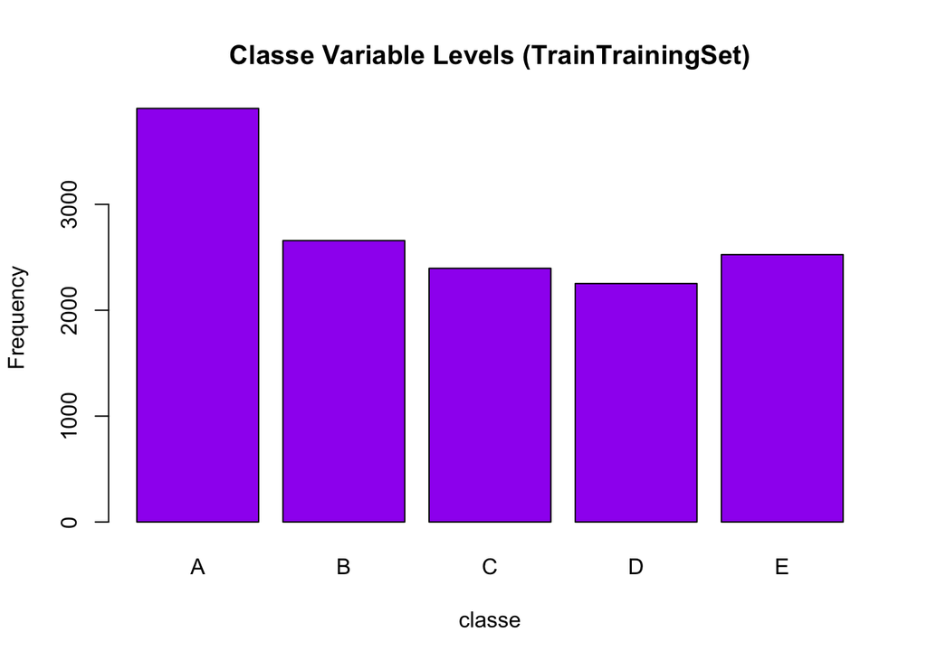

```r
training <- "http://d396qusza40orc.cloudfront.net/predmachlearn/pml-training.csv"

testing <- "http://d396qusza40orc.cloudfront.net/predmachlearn/pml-testing.csv"

trainingset <- read.csv(url(training), na.strings=c("NA","#DIV/0!",""))

testingset <- read.csv(url(testing), na.strings=c("NA","#DIV/0!",""))

# Perform exploratory analysis,  -
# dim(trainingset); dim(testingset);
#summary(trainingset); summary(testingset);
#str(trainingset); str(testingset);
#head(trainingset); head(testingset);
#these are commented out to save space

# Delete columns with all missing values, we do not these to offset out results
trainingset<-trainingset[,colSums(is.na(trainingset)) == 0]
testingset <-testingset[,colSums(is.na(testingset)) == 0]

# Delete variables are irrelevant to our current project (user_name, raw_timestamp_part_1, raw_timestamp_part_,2 cvtd_timestamp, new_window, and  num_window (columns 1 to 7)).
#We really just want to know about their health and times
trainingset   <-trainingset[,-c(1:7)]
testingset <-testingset[,-c(1:7)]

# partition the data so that 70% of the training dataset into training and the remaining 30% to testing
traintrainset <- createDataPartition(y=trainingset$classe, p=0.70, list=FALSE)
TrainTrainingSet <- trainingset[traintrainset, ]
TestTrainingSet <- trainingset[-traintrainset, ]

# A plot of the outcome variable will allow us to see the frequency of each levels in the TrainTrainingSet data set and compare one another.

plot(TrainTrainingSet$classe, col="purple", main="Classe Variable Levels (TrainTrainingSet)", xlab="classe", ylab="Frequency")
```

## Random Forest

```r
model2 <- randomForest(classe ~. , data=TrainTrainingSet, method="class")

# Predicting:
prediction2 <- predict(model2, TestTrainingSet, type = "class")

# Test results on TestTrainingSet data set:
confusionMatrix(prediction2, TestTrainingSet$classe)
```

```
## Confusion Matrix and Statistics
##
##           Reference
## Prediction    A    B    C    D    E
##          A 1668    9    0    0    0
##          B    6 1127    2    0    0
##          C    0    3 1023    5    0
##          D    0    0    1  959    2
##          E    0    0    0    0 1080
##
## Overall Statistics
##
##                Accuracy : 0.9952
##                  95% CI : (0.9931, 0.9968)
##     No Information Rate : 0.2845
##     P-Value [Acc > NIR] : < 2.2e-16
##
##                   Kappa : 0.994
##  Mcnemar's Test P-Value : NA
##
## Statistics by Class:
##
##                      Class: A Class: B Class: C Class: D Class: E
## Sensitivity            0.9964   0.9895   0.9971   0.9948   0.9982
## Specificity            0.9979   0.9983   0.9984   0.9994   1.0000
## Pos Pred Value         0.9946   0.9930   0.9922   0.9969   1.0000
## Neg Pred Value         0.9986   0.9975   0.9994   0.9990   0.9996
## Prevalence             0.2845   0.1935   0.1743   0.1638   0.1839
## Detection Rate         0.2834   0.1915   0.1738   0.1630   0.1835
## Detection Prevalence   0.2850   0.1929   0.1752   0.1635   0.1835
## Balanced Accuracy      0.9971   0.9939   0.9977   0.9971   0.9991
```

## Decision Tree

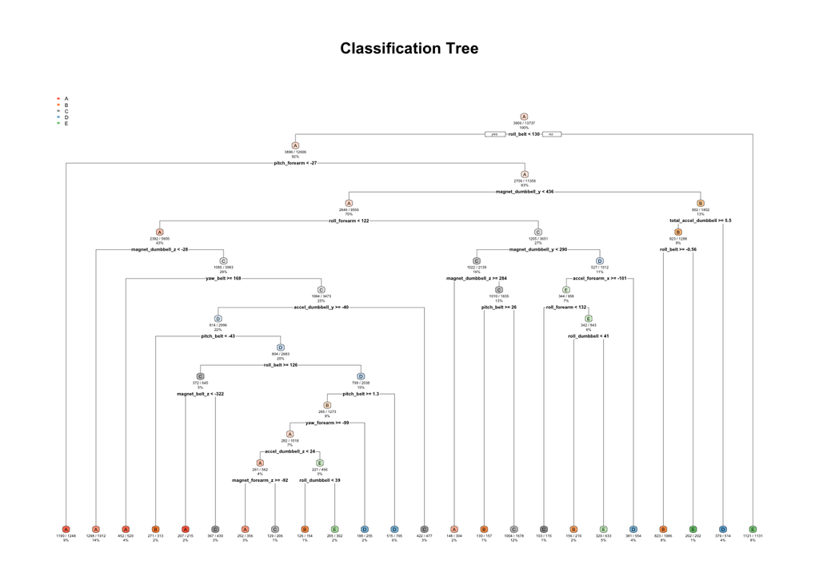

```r
model1 <- rpart(classe ~ ., data=TrainTrainingSet, method="class")

prediction1 <- predict(model1, TestTrainingSet, type = "class")

# Plot the Decision Tree
rpart.plot(model1, main="Classification Tree", extra=102, under=TRUE, faclen=0)
```

```r
# Testing results on TestTrainingSet data set:
confusionMatrix(prediction1, TestTrainingSet$classe)
```

```
## Confusion Matrix and Statistics
##
##           Reference
## Prediction    A    B    C    D    E
##          A 1501  268   22  126   56
##          B   53  617   48   16   64
##          C   34  117  863  146  128
##          D   61   75   71  602   56
##          E   25   62   22   74  778
##
## Overall Statistics
##
##                Accuracy : 0.741
##                  95% CI : (0.7296, 0.7522)
##     No Information Rate : 0.2845
##     P-Value [Acc > NIR] : < 2.2e-16
##
##                   Kappa : 0.6706
##  Mcnemar's Test P-Value : < 2.2e-16
##
## Statistics by Class:
##
##                      Class: A Class: B Class: C Class: D Class: E
## Sensitivity            0.8967   0.5417   0.8411   0.6245   0.7190
## Specificity            0.8879   0.9619   0.9125   0.9466   0.9619
## Pos Pred Value         0.7608   0.7732   0.6700   0.6960   0.8096
## Neg Pred Value         0.9558   0.8974   0.9645   0.9279   0.9383
## Prevalence             0.2845   0.1935   0.1743   0.1638   0.1839
## Detection Rate         0.2551   0.1048   0.1466   0.1023   0.1322
## Detection Prevalence   0.3353   0.1356   0.2189   0.1470   0.1633
## Balanced Accuracy      0.8923   0.7518   0.8768   0.7855   0.8405
```

## Submission

```r
# predict outcome levels on the original Testing data set using Random Forest algorithm
predictfinal <- predict(model2, testingset, type="class")
predictfinal
```

```
##  1  2  3  4  5  6  7  8  9 10 11 12 13 14 15 16 17 18 19 20
##  B  A  B  A  A  E  D  B  A  A  B  C  B  A  E  E  A  B  B  B
## Levels: A B C D E
```